# Reproducible Workflows for Intensive Longitudinal Data Analysis in R: A use case demonstrating R Markdown and reproducibleRchunks

Andreas M. Brandmaier

21 Oktober 2026

# Overview

This document is part of the Open Materials accompanying the book chapter

> Brandmaier, A. M. (in press). Reproducible Workflows for Intensive Longitudinal Data Analysis in R. In T. Koch, T. Lischetzke, & J. Holtmann (Eds.), *Handbook of intensive longitudinal data analysis*. Routledge.

**Goal.** Demonstrate tools for reproducible research workflows with intensive longitudinal data. Specifically, we

1. recreate a panel from Figure 1 of Kossakowski et al. (2017),
2. fit a linear model for the time trend in the weekly depression ratings, and
3. use the `cocoon` package to write the model statistics **directly into the running text**, so that the numbers in the manuscript can never drift out of sync with the analysis.

**Important caveat.** The study has several phases, which are *not* modeled here. The analysis serves only as an illustration of the workflow; we draw no substantive conclusions.

## Data

We use the data from Kossakowski, Groot, Haslbeck, Borsboom, and Wichers (2017), “Data from ‘Critical Slowing Down as a Personalized Early Warning Signal for Depression’”, *Journal of Open Psychology Data, 5*(1), [doi:10.5334/jopd.29](https://doi.org/10.5334/jopd.29) (OSF: https://osf.io/j4fg8, license CC BY 4.0).

The dataset is a single-case (N = 1) experience-sampling study with roughly 1,470 momentary observations (about 10 beeps per day over 239 days, 50 items). The participant is male, aged 57, has a history of multiple episodes of major depression, and had been using antidepressants for the previous 8.5 years. He monitored his momentary experiential states over the course of a gradual discontinuation of his antidepressant. Depressive symptoms were additionally assessed **weekly** with the SCL-90-R depression subscale (variable `dep`).

```r
library(tidyr)
library(dplyr)
library(ggplot2)
library(cocoon)
library(scales)
```

# Load and preprocess data

```r
raw <- read.csv("data/ESMdata.csv")
```

Preprocessing steps:

- parse the date and check that parsing did not produce missing values,
- sort by date and beep number so that “first” means “earliest beep”,
- compute the day of the study (starting from zero).

```r
raw$date <- as.Date(raw$date, format = "%d/%m/%y")
stopifnot(!anyNA(raw$date))

raw <- raw[order(raw$date, raw$beepno), ]
raw$day <- as.numeric(raw$date - min(raw$date))
```

The weekly depression rating is only recorded once per week and is missing at all other beeps. We create two versions of the data:

- `beeps`: the weekly rating is carried forward to all following beeps. This is used for the plot, which shows the rating as a step function over time.
- `weekly`: **one row per actual weekly assessment**, derived from the *unfilled* data. This is used for the model. (If we derived it from the filled data, the first row of each week would often contain the previous week’s rating carried forward.)

Here, we use an R chunk of the type `reproducibleR` that adds an automated reproducibility check of the preprocessing step. A reproduction report is automatically generated and inserted into the document.

```r
beeps <- raw |>
  tidyr::fill(dep, .direction = "down")

weekly <- raw |>
  filter(!is.na(dep)) |>
  distinct(date, dep, .keep_all = TRUE) |>
  mutate(week = floor(day / 7) + 1)
```

##### Code Chunk Reproduction Report

- ✅beeps: REPRODUCTION SUCCESSFUL
- ✅weekly: REPRODUCTION SUCCESSFUL

The data contain 1476 beeps and 28 weekly depression assessments.

# Plot

The following code recreates the SCL-90-R depression subscale panel of Figure 1a in Kossakowski et al. (2017). The dashed line is the linear trend of the weekly ratings, i.e., the same data and the same model that we report below.

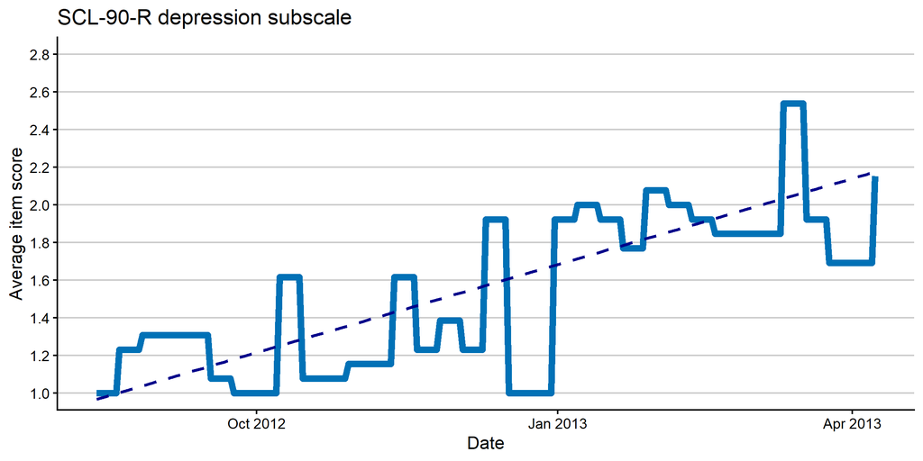

Weekly SCL-90-R depression subscale (average item score) over the course of the study. The dashed line is the linear time trend estimated from the weekly assessments.

```r
p <- ggplot(beeps, aes(x = date, y = dep)) +
  geom_line(linewidth = 2, color = "#0171b6") +
  geom_smooth(
    data = weekly, method = "lm", formula = y ~ x,
    color = "darkblue", linetype = "dashed", se = FALSE
  ) +
  scale_y_continuous(breaks = scales::breaks_width(0.2)) +
  coord_cartesian(ylim = c(1, 2.8)) +
  labs(
    title = "SCL-90-R depression subscale",
    x = "Date",
    y = "Average item score"
  ) +
  theme_classic() +
  theme(
    panel.grid.major.y = element_line(color = "grey80", linewidth = 0.5),
    panel.grid.minor.y = element_blank()
  )+
  scale_x_date(
    labels = scales::label_date("%b %Y", locale = "en")
  )

p
```

Because the plot is stored in an object (`p`), we can reuse it elsewhere (`ggsave()`, other documents) without re-running or copying any code.

```r
ggsave("output/fig_depression.png", p, width = 8, height = 4)
```

# Model

We fit a simple linear model to estimate the time trend of the weekly depression ratings across **all** phases of the study (which does not do justice to the design). It tests only the linear component of change in depression over time. Again, we use an R chunk of type `reproducibleR` to insert a reproduction test of the fitted model:

```r
model <- lm(dep ~ week, data = weekly)
summary(model)
```

```
##
## Call:
## lm(formula = dep ~ week, data = weekly)
##
## Residuals:
##      Min       1Q   Median       3Q      Max
## -0.60660 -0.20517 -0.01845  0.23297  0.50571
##
## Coefficients:
##             Estimate Std. Error t value Pr(>|t|)
## (Intercept) 0.931017   0.107923   8.627 4.18e-09 ***
## week        0.035557   0.005323   6.679 4.37e-07 ***
## ---
## Signif. codes:  0 '***' 0.001 '**' 0.01 '*' 0.05 '.' 0.1 ' ' 1
##
## Residual standard error: 0.2704 on 26 degrees of freedom
## Multiple R-squared:  0.6318, Adjusted R-squared:  0.6176
## F-statistic: 44.61 on 1 and 26 DF,  p-value: 4.37e-07
```

##### Code Chunk Reproduction Report

- ✅model: REPRODUCTION SUCCESSFUL

Save the fitted model so that downstream documents (e.g., the manuscript) can load it without re-fitting:

```r
saveRDS(model, "output/model_esm.rds")
```

# Reporting results with `cocoon`

Copying numbers from console output into a manuscript is error-prone. The `cocoon` package formats the statistics of a fitted model so that they can be embedded directly into text. The function `format_stats()` takes a model object and returns a formatted string; with the argument `term`, it restricts the output to a single model term.

## Whole-model statistics

```r
cat(cocoon::format_stats(model))
```

*R*<sup>2</sup> = 0.618, *F*(1, 26) = 44.613, *p* < .001

## Statistics for a single term

```r
cat(cocoon::format_stats(model, term = "week"))
```

*β* = 0.036, SE = 0.005, *t* = 6.679, *p* < .001

## Inline use in running text

The real benefit comes from calling `cocoon` **inline**, i.e., inside the sentence. The following sentence is written in R Markdown as `` Depression ratings changed linearly over time (`r cocoon::format_stats(model, term = "week")`). `` and renders as:

> Depression ratings changed linearly over time (*β* = 0.036, SE = 0.005, *t* = 6.679, *p* < .001).

Likewise, the overall model fit can be reported as *R*<sup>2</sup> = 0.618, *F*(1, 26) = 44.613, *p* < .001.

If the data, the preprocessing, or the model change, simply knit the document again: the figure, the table output, and every number in the text update automatically.

## Putting it together in a manuscript

In a manuscript (`.Rmd` or Quarto), the pattern is:

1. run the analysis in code chunks (as above) and keep the model objects,
2. reference results only through inline calls such as `` `r cocoon::format_stats(model, term = "week")` ``,
3. include figures via chunks and `fig.cap`, never as pasted images,
4. track the document, the data (or a pointer to it), and the `renv.lock` file in version control.

# References

Kossakowski, J. J., Groot, P. C., Haslbeck, J. M. B., Borsboom, D., & Wichers, M. (2017). Data from “Critical slowing down as a personalized early warning signal for depression”. *Journal of Open Psychology Data, 5*(1). https://doi.org/10.5334/jopd.29